# 22_Descriptives

Adrian Stanciu & Ranjit Singh

26 January, 2022

Descriptive statistics are one way of looking at the data and exploring or understanding their patterns. This set of statistics is descriptive because, well, it only describes the data without performing any tests, that fits rather in the category inferential statistics.

For this seminar we can of course not cover all the possibilities. We focus on

- frequencies
- correlations
- and visualizing data

# Frequencies

## Basics

We’ve covered frequencies in the session before. These help to understand how the data is structured, and in fact we can think of it as a form of data aggregation, at least in `R` terms.

Let us once more calculate frequencies for some of the variables in the ALLBUS data set. And let us also inspect the data frame and get an quick overview of its contents.

```r
# insepcts the data frame
glimpse(df_allbus)
```

```
## Rows: 3,477
## Columns: 30
## $ sex        <dbl> 1, 2, 1, 1, 2, 1, 2, 1, 2, 2, 1, 2, 1, 1, 2, 1, 1, 1, 1, 1,~
## $ age        <dbl> 62, 64, 22, 59, 30, 41, 43, 39, 40, 69, 37, 77, 73, 46, 68,~
## $ work       <dbl> 1, 1, 1, 4, 1, 1, 2, 1, 2, 4, 1, 4, 4, 1, 4, 1, 1, 4, 4, 1,~
## $ german     <dbl> 1, 1, 1, 1, 1, 1, 1, 1, 1, 1, 1, 1, 1, 1, 1, 1, 2, 1, 1, 1,~
## $ ep01       <dbl> 1, 2, 2, 2, 3, 1, 3, 2, 1, 2, 3, 3, 1, 2, 3, 1, 2, 3, 3, 3,~
## $ ep03       <dbl> 2, 4, 2, 2, 2, 3, 2, 3, 2, 2, 3, 3, 2, 2, 3, 4, 2, 2, 4, 3,~
## $ ep04       <dbl> 2, 3, 3, 3, 3, 3, 3, 3, 4, 2, 3, 4, 3, 3, 4, 3, 2, 1, 4, 3,~
## $ ep06       <dbl> 3, 3, 2, 3, 2, 2, 3, 2, 3, 3, 3, 3, 3, 3, 3, 2, 1, 3, 3, 3,~
## $ pa01       <dbl> 5, 7, 5, 5, 5, 6, 5, 3, 7, 2, 7, NA, 5, 3, 5, 5, NA, 5, 3, ~
## $ pa02a      <dbl> 2, 3, 3, 2, 3, 3, 2, 1, 5, 2, 4, 4, 2, 2, 3, 3, 4, 3, 2, 2,~
## $ ls01       <dbl> 9, 5, 10, 10, 8, 6, 8, 8, 7, 9, 8, 6, 10, 9, 5, 10, 9, 6, 9~
## $ pa17       <dbl> 2, 4, 3, 4, 3, 3, 1, 1, 3, 3, 4, 5, 5, 1, 4, 5, 1, 1, 3, 2,~
## $ pv20       <dbl> 6, 2, 7, 10, 4, 4, 5, 10, 6, 10, 3, 2, 10, 3, 6, 1, NA, 8, ~
```

[output cut: 17 more lines]

If we look at the factor versions “_fct”, we can alrady guess that some variables are more categorical (e.g., `work_fct`), while others are metric (e.g., `age`), or (pseudo-)metric (e.g., `ep01_fct`). Some variables remain cryptic, however. Look at `pa01_fct`. What are those letters?

Fortunately, we have saved all variable labels to `allbus_labels`! We can look into that data frame manually, or just use `fetch_var_lab()` (but without the suffix).

```r
fetch_var_lab("pa01", allbus_labels)
```

```
## [1] "SELF-PLACEMENT ON LEFT-RIGHT CONTINUUM"
```

```r
# Fun fact: The variable has letters as value labels, because the ALLBUS shows respondents a showcard with letters instead of numbers for left-right orientation
```

Let us check the frequencies of these two variables.

First `ls01`, which is overall life satisfaction:

```r
fetch_var_lab("ls01", allbus_labels)
```

```
## [1] "OVERALL LIFE SATISFACTION"
```

```r
# frequencies for ls01

freq_ls01 <- df_allbus %>%
  group_by(ls01) %>%  # Note how we group by the variable itself, thus making unique responses to groups!
  summarise(n=n()) %>%
  ungroup() %>%
  mutate(rel_freq = 100*n / sum(n),
           cum_freq = 100*cumsum(rel_freq/sum(rel_freq)))
freq_ls01
```

```
## # A tibble: 12 x 4
##     ls01     n rel_freq cum_freq
##    <dbl> <int>    <dbl>    <dbl>
##  1     0    13   0.374     0.374
##  2     1    12   0.345     0.719
##  3     2    31   0.892     1.61
##  4     3    52   1.50      3.11
##  5     4    64   1.84      4.95
##  6     5   207   5.95     10.9
##  7     6   224   6.44     17.3
##  8     7   511  14.7      32.0
##  9     8  1097  31.6      63.6
## 10     9   759  21.8      85.4
## 11    10   506  14.6     100.
## 12    NA     1   0.0288  100
```

A quick note on `ungroup()`. We ungroup before `mutate()`, because with groups, `sum()` would only sum up within a group! However, that is actually unnecessary here, because summary() always removes one “layer of grouping”. Here it has removed the grouping by `ls01`. Still, we recommend to `ungroup()` manually, because it is easy to get confused with several grouping variables.

```r
# Note how the output is no longer grouped!
is_grouped_df(freq_ls01)
```

```
## [1] FALSE
```

```r
# Bonus tipp: We can rename variables with their var labels in the allbus_labels df!
# This is great for reports or graphs.
# The code is a bit strange, but it shows how helpful such fetch functions are :)

freq_ls01 %>%
rename_with(.cols = ls01, ~fetch_var_lab(.x, allbus_labels))
```

```
## # A tibble: 12 x 4
##    `OVERALL LIFE SATISFACTION`     n rel_freq cum_freq
##                          <dbl> <int>    <dbl>    <dbl>
##  1                           0    13   0.374     0.374
##  2                           1    12   0.345     0.719
##  3                           2    31   0.892     1.61
##  4                           3    52   1.50      3.11
##  5                           4    64   1.84      4.95
##  6                           5   207   5.95     10.9
##  7                           6   224   6.44     17.3
##  8                           7   511  14.7      32.0
##  9                           8  1097  31.6      63.6
## 10                           9   759  21.8      85.4
## 11                          10   506  14.6     100.
## 12                          NA     1   0.0288  100
```

Now let us do the same for work (i.e., current employment status).

```r
# frequencies for work

freq_work <- df_allbus %>%
  group_by(work_fct) %>% # Note that we use work_fct instead of work!
  summarise(n=n()) %>%
  mutate(rel_freq = 100*n / sum(n),
           cum_freq = 100*cumsum(rel_freq/sum(rel_freq))) %>%
  ungroup()
freq_work
```

```
## # A tibble: 4 x 4
##   work_fct                n rel_freq cum_freq
##   <fct>               <int>    <dbl>    <dbl>
## 1 EMPLOYED, FULL-TIME  1568    45.1      45.1
## 2 EMPLOYED, PART-TIME   403    11.6      56.7
## 3 LESS THAN PART-TIME   168     4.83     61.5
## 4 NOT WORKING          1338    38.5     100
```

## Outlook: Automation with `purrr::map()`

Repetetive code is often easily automated in R. Imagine we want frequency tables for all variables.

That can be easily done with `map()`, which we will discuss tomorrow. In short, the family of map functions from `purrr::` applies a function to each element in a vector or dataframe or list.

Here, we enrich the allbus_labels dataframe, by adding frequency tables!

```r
# Function that takes a vector and a name and creates a frequency table
generate_freq_tab <- function(variable){
  tibble(variable) %>%
    group_by(responses = variable) %>%
    summarise(abs_freq= n()) %>%
  mutate(
    rel_freq=abs_freq*100/sum(abs_freq),
    cum_rel_freq = 100*cumsum(rel_freq/sum(rel_freq))
  )
}

# Apply the function to all variables listed in allbus_labels
# Note how we use allbus_labels for the variable names, but then draw data from df_allbus!

labels_and_tables <- allbus_labels %>%
  select(-value_labels) %>%
  mutate(
    frequency_tabs = map(paste0(var_name, "_fct"),
                          ~ generate_freq_tab(df_allbus[[.x]]))
  )

# If we want to access the frequency table, we can simply unnest() it.
# This creates a long-format data frame, ideal for further analyses

# This is what it looks like for the variable "work":

labels_and_tables %>%
  filter(var_name == "work") %>%
  unnest(frequency_tabs)
```

```
## # A tibble: 4 x 6
##   var_name variable_label           responses     abs_freq rel_freq cum_rel_freq
##   <chr>    <chr>                    <fct>            <int>    <dbl>        <dbl>
## 1 work     RESPONDENT: CURRENT EMP~ EMPLOYED, FU~     1568    45.1          45.1
## 2 work     RESPONDENT: CURRENT EMP~ EMPLOYED, PA~      403    11.6          56.7
## 3 work     RESPONDENT: CURRENT EMP~ LESS THAN PA~      168     4.83         61.5
## 4 work     RESPONDENT: CURRENT EMP~ NOT WORKING       1338    38.5         100
```

# Descriptive stats in general

## Correlations

### Basics

1. For metric variables

This is the Pearson’s correlation that we mostly think of when we want to inspect the correlation between variables. For such correlations we should only use continuous observations.

The command to use is `cor()`.

Let us use the ALLBUS data and inspect the correlation coefficient between `ep03` (Respondent’s current financial situation) and `ls01` (Overall life satisfaction of respondent).

```r
# Pearson's r correlation coefficient
pearson_r_ep03_ls01_v1 <- cor(df_allbus$ep03, # defines variable 1
                           df_allbus$ls01, # defines variable 2
                           method="pearson", # defines which correlation type to calculate
                           use="complete.obs") # specifies that missing data should not be considered
pearson_r_ep03_ls01_v1
```

```
## [1] -0.4545291
```

This gives us what we want, the `r` coefficient, but we cannot tell whether there is a significant *p* value associated with it or not. We can use instead the command `cor.test()` which is more informative than `cor()`.

The output gives us the `t`-value of the test, associated `df` (degrees of freedom), and the `p`-value associated with the t-test. Moreover, we also get the 95% confidence interval, and of course the looked after `r` coefficient.

```r
# Pearson's r correlation coefficient
pearson_r_ep03_ls01_v2 <- cor.test(df_allbus$ep03, # defines variable 1
                           df_allbus$ls01, # defines variable 2
                           method="pearson", # defines which correlation type to calculate
                           use="complete.obs") # specifies that missing data should not be considered
pearson_r_ep03_ls01_v2
```

```
##
##  Pearson's product-moment correlation
##
## data:  df_allbus$ep03 and df_allbus$ls01
## t = -30.059, df = 3470, p-value < 2.2e-16
## alternative hypothesis: true correlation is not equal to 0
## 95 percent confidence interval:
##  -0.4805284 -0.4277315
## sample estimates:
##        cor
## -0.4545291
```

2. For non-normal or ordinal variables

If instead we want to inspect the correlation coefficient between two ordinal variables, we simply change the method argument in the above functions.

Say we want to inspect the correlation between `sex` and `german` (whether a participant holds German nationality or not).

```r
# kendall tau correlation coefficient
kendall_sex_german <- cor.test(df_allbus$sex,
                               df_allbus$german,
                               method = "kendall",
                               use="complete.obs")
kendall_sex_german
```

```
##
##  Kendall's rank correlation tau
##
## data:  df_allbus$sex and df_allbus$german
## z = -1.2025, p-value = 0.2292
## alternative hypothesis: true tau is not equal to 0
## sample estimates:
##         tau
## -0.02039551
```

## Effect size Cohen’s d

Measures of effect size in general are informative on top of reporting the p-value (significance test) of your test. Effect size measures inform about how meaningful a found effect is given the observed data.

Perhaps the most common effect size measure is Cohen’s *d*. A nice visualization tool on intepreting and understanding Cohen’s *d* and its relation to data can be seen [here](https://rpsychologist.com/cohend/).

Though, Cohen did not intend on suggesting thresholds for interpreting observed *d* values, it has become sort of a standard procedure to evaluate the strength of an effect according to these thresholds:

- small effect: *d* >= 0.2
- medium effect: *d* >= 0.5
- large effect: *d* >= 0.8

Remember that Cohen’s *d* is an effect size measure for experimental data, otherwise said for comparisons of means across groups.

Let us pretend in the ALLBUS data we have experimental information (we’ve conducted an experiment of sorts) on the `pv22` “Probability to vote for the GREEENS if elections were held next week” and we want to compare men and women, thus the “treatment” condition is whether someone is a female or a man (`sex`).

```r
# calculates cohen's d for the group comparison men~women on intention to vote for greens
cohen_d_sex_pv22 <- psych::cohen.d(df_allbus$pv22,
                                   group=df_allbus$sex)

cohen_d_sex_pv22
```

```
## Call: psych::cohen.d(x = df_allbus$pv22, group = df_allbus$sex)
## Cohen d statistic of difference between two means
##      lower effect upper
## [1,]  0.11   0.18  0.25
##
## Multivariate (Mahalanobis) distance between groups
## [1] 0.18
## r equivalent of difference between two means
## data
## 0.09
```

# Data visualization

Data visualization in `R` can be done in multiple ways, in base `R` (where you do not need to install extra packages) or using a multitude of extra packages.

Luckily there is one particular package that is so powerful that you’d only need this one for everything you’d desire - this package is `ggplot2`.

See [here](https://ggplot2-book.org/) for one guide on how to make the best of this data visualization package.

## Histogram

Simple histogram.

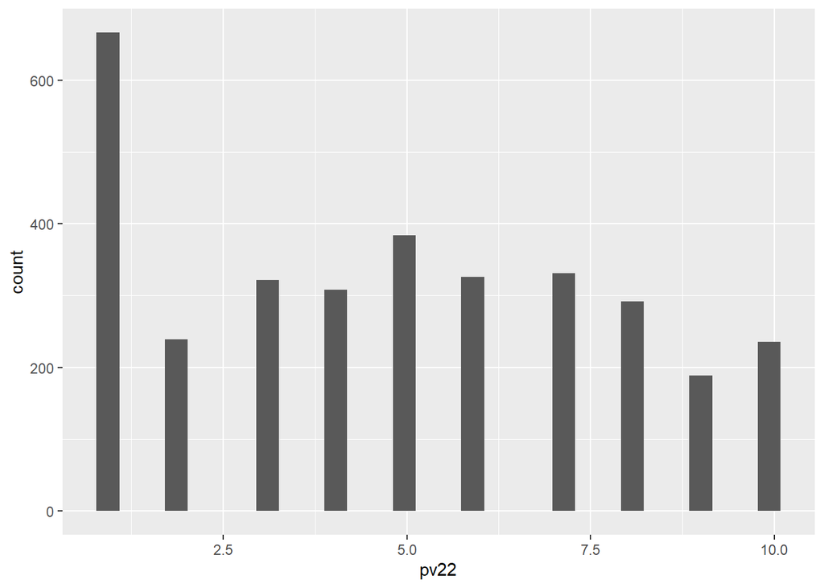

```r
# creates a simple histogram
p_hist_1 <- df_allbus %>% # defines what data to use
  ggplot(aes(x=pv22)) + # activates the ggplot command and specifies the x: axis
  geom_histogram() # indicates what plot to create

p_hist_1
```

Histogram with modified bars.

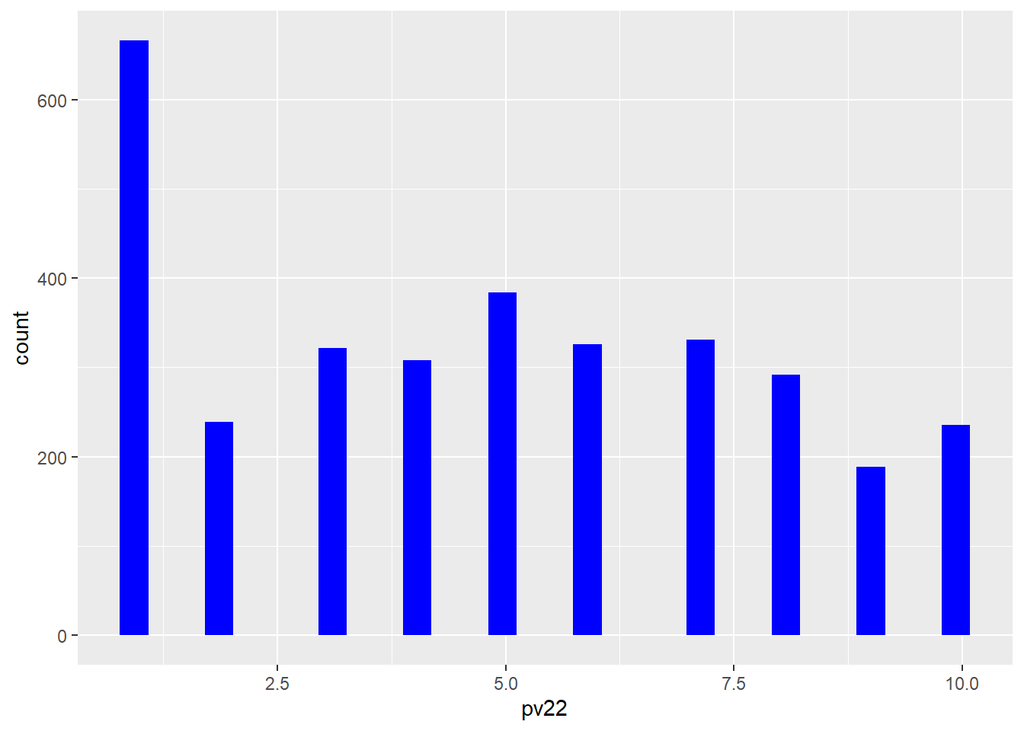

```r
# changes color of histogram bars
p_hist_2 <- df_allbus %>%
  ggplot(aes(x=pv22)) +
  geom_histogram(fill = "blue") # inside the brackets you can further modify elements of the histogram itself

p_hist_2
```

Histogram for grouped variable.

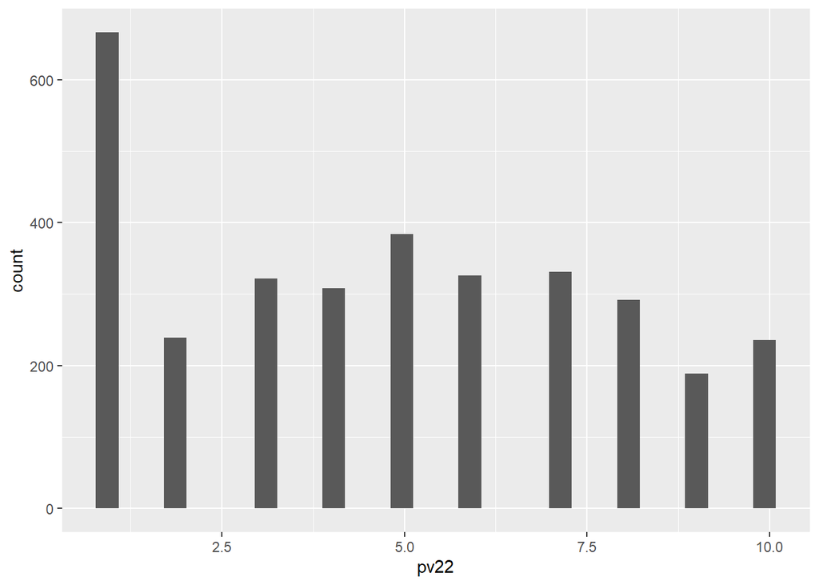

```r
# adds a grouping variable to the histogram plot
p_hist_3.1 <- df_allbus %>%
  ggplot(aes(pv22,
             fill=sex)) +
  geom_histogram()

p_hist_3.1
```

```r
# the above doesn't give the desired output because the data would need first to be transformed into long format
# first, we transform data into long format

longdf_p_hist_3.2 <- df_allbus %>%
  select(sex,pv22) %>%
  group_by(sex) %>%
  pivot_longer(pv22)

# inspect the new data to see the column names
head(longdf_p_hist_3.2)
```

```
## # A tibble: 6 x 3
## # Groups:   sex [2]
##     sex name  value
##   <dbl> <chr> <dbl>
## 1     1 pv22      7
## 2     2 pv22      2
## 3     1 pv22      4
## 4     1 pv22      1
## 5     2 pv22      4
## 6     1 pv22      1
```

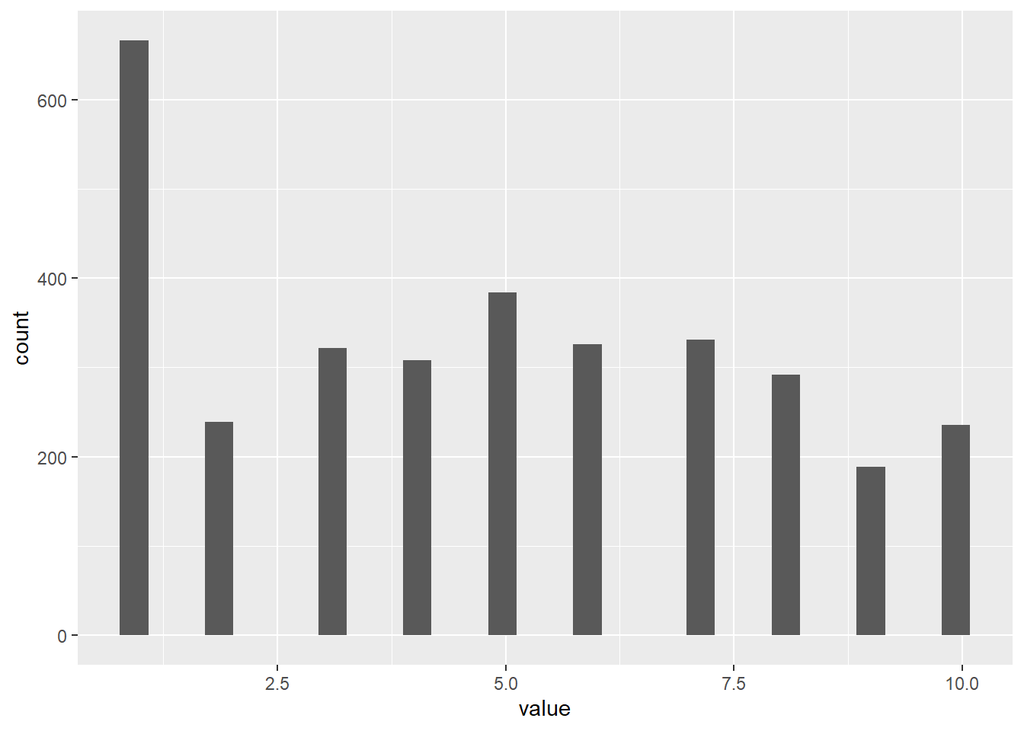

```r
#  creates grouped histogram
p_hist_3.2 <- longdf_p_hist_3.2 %>%
  ggplot(aes(x=value,
             fill=sex)) +
  geom_histogram()
p_hist_3.2
```

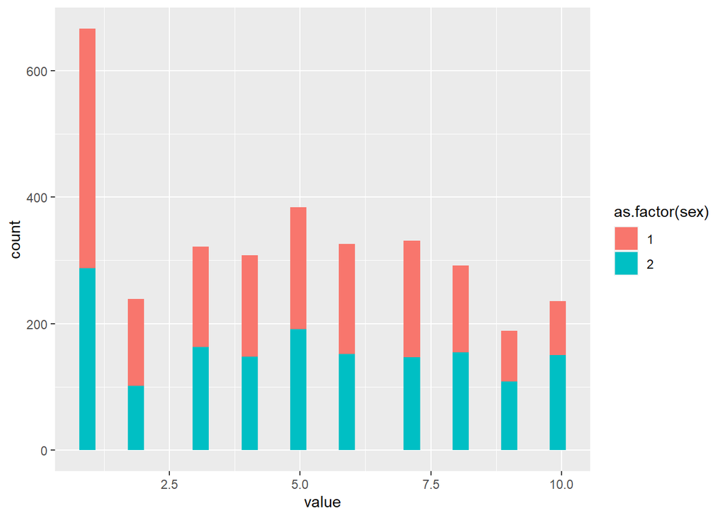

```r
# still doesn't give the right output
# and that is because the data frame as it is stores "sex" as a numeric variable
# R and ggplot needs to be told that "sex" is a factor so that it fits the argument "group", "fill" or "shape",
# after which the grouping of the histogram can be developed

p_hist_3.3 <- longdf_p_hist_3.2 %>%
  ggplot(aes(x=value,
             fill=as.factor(sex))) +
  geom_histogram()
p_hist_3.3
```

More tips on building historgrams can be found [here](https://r-charts.com/distribution/histogram-group-ggplot2/).

## Scatter plots (bivariate plots)

These type of plots are useful for visualizing correlations and regression trends, for instance.

Scatter plot.

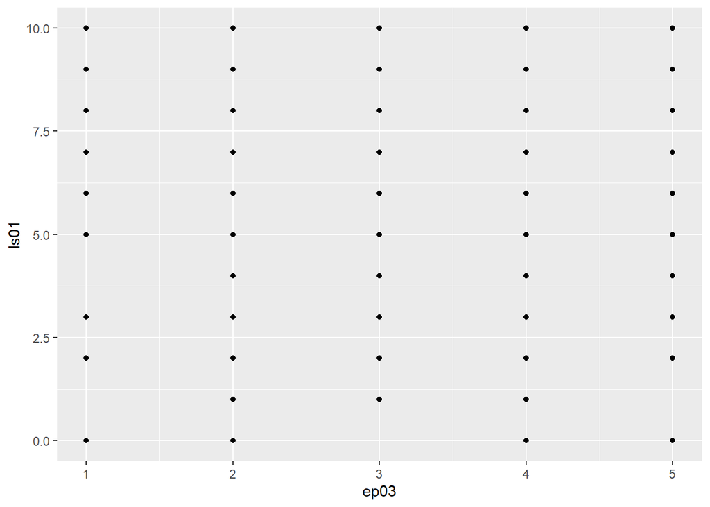

```r
# creates scatter plot for life satisfaction (ls01) and current economic situation participant (ep03)
p_scatter_1 <- df_allbus %>%
  ggplot(aes(y=ls01,
             x=ep03)) +
  geom_point()

p_scatter_1
```

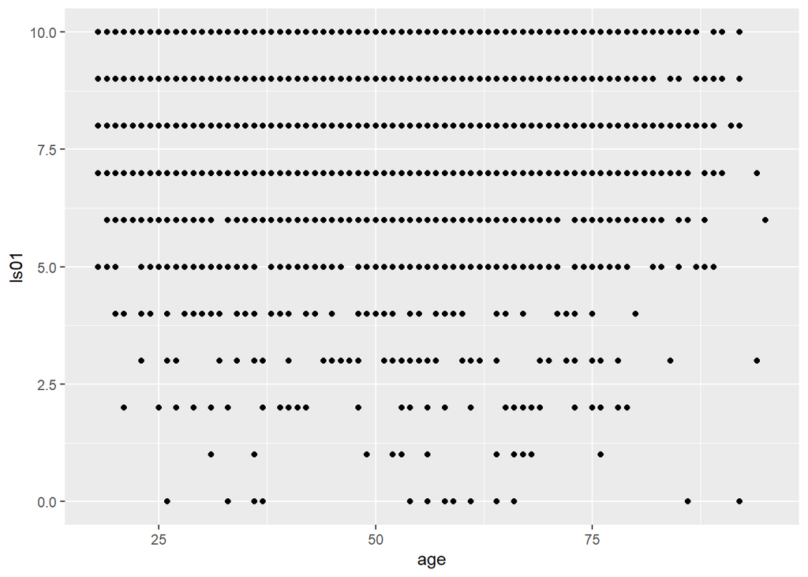

```r
## this is difficult to read - see explanation on the slides
## let's try again, but this time we change ep03 for age of participants
p_scatter_2 <- df_allbus %>%
  ggplot(aes(y=ls01,
             x=age)) +
  geom_point()

p_scatter_2
```